# Austo

## Data Dictionary (columns in austo_automobile.csv)

- **Age**: Age of the customer
- **Gender**: Male/Female
- **Profession**: Customer’s profession
- **Marital_status**: Married/Single
- **Education**: Highest education (High School, Graduate, Post Graduate)
- **No_of_Dependents**: Number of dependents (0–4)
- **Personal_loan**: Whether the customer has a personal loan (Yes/No)
- **House_loan**: Whether the customer has a house loan (Yes/No)
- **Partner_working**: Whether customer’s partner is working (Yes/No)
- **Salary**: Annual salary of the customer (USD)
- **Partner_salary**: Annual salary of partner (USD)
- **Total_salary**: Sum of Salary + Partner_salary (USD)
- **Price**: Price of purchased car (USD)
- **Make**: Car type (Hatchback/Sedan/SUV)

# Austo Automobile Buyer Profiling

## Problem Statement

Austo (a UK-based auto company) plans to enter the US market. To decide positioning for Hatchback, Sedan, and SUV, we analyze a dataset of 1,581 buyers with demographics, finances, and purchase preferences.

**Objectives**

1. Build clear buyer profiles for each car type (Hatchback, Sedan, SUV).
2. Translate findings into actionable recommendations (pricing, financing, targeting).

```python
# Core analysis packages
import pandas as pd            # data frames and data manipulation
import numpy as np             # numerical computing helpers
import matplotlib.pyplot as plt # plotting library (built-in with Jupyter)

# Statistical tests (optional but nice to have for evidence)
from scipy import stats
from scipy.stats import chi2_contingency

# Make numeric printing cleaner (e.g., 12345 → 12,345.00)
pd.set_option("display.float_format", lambda x: f"{x:,.2f}")

# Make all plots a bit larger so labels are readable
plt.rcParams["figure.figsize"] = (8,5)
```

```python
# Ensure the CSV is in the same folder as your notebook.
# If not, provide the full path: pd.read_csv("/path/to/austo_automobile.csv")
df = pd.read_csv(r"C:\Users\zinia\Downloads\austo_automobile.csv")

# Peek at the first 5 rows to confirm successful load and column names
df.head()
```

|  | Age | Gender | Profession | Marital_status | Education | No_of_Dependents | Personal_loan | House_loan | Partner_working | Salary | Partner_salary | Total_salary | Price | Make |
| --- | --- | --- | --- | --- | --- | --- | --- | --- | --- | --- | --- | --- | --- | --- |
| 0 | 24 | Male | Salaried | Married | Post Graduate | 4 | No | Yes | Yes | 52000 | 25000 | 77000 | 18000 | Hatchback |
| 1 | 28 | Male | Salaried | Married | Post Graduate | 3 | No | Yes | No | 68000 | 0 | 68000 | 18000 | Hatchback |
| 2 | 23 | Male | Salaried | Married | Graduate | 4 | Yes | Yes | No | 31000 | 0 | 31000 | 18000 | Hatchback |
| 3 | 26 | Male | Business | Married | Post Graduate | 4 | Yes | Yes | Yes | 66000 | 35000 | 101000 | 18000 | Hatchback |
| 4 | 28 | Male | Business | Married | Post Graduate | 4 | Yes | No | No | 64000 | 0 | 64000 | 18000 | Hatchback |

```python
# (rows, columns) → sanity check against assignment (should be 1581 x 14)
print("Rows, Columns:", df.shape)

# .info() shows data types and non-null counts.
# Use this to confirm expected numeric vs categorical types.
df.info()
```

```
Rows, Columns: (1581, 14)
<class 'pandas.core.frame.DataFrame'>
RangeIndex: 1581 entries, 0 to 1580
Data columns (total 14 columns):
 #   Column            Non-Null Count  Dtype
---  ------            --------------  -----
 0   Age               1581 non-null   int64
 1   Gender            1581 non-null   object
 2   Profession        1581 non-null   object
 3   Marital_status    1581 non-null   object
 4   Education         1581 non-null   object
 5   No_of_Dependents  1581 non-null   int64
 6   Personal_loan     1581 non-null   object
 7   House_loan        1581 non-null   object
 8   Partner_working   1581 non-null   object
 9   Salary            1581 non-null   int64
 10  Partner_salary    1581 non-null   int64
 11  Total_salary      1581 non-null   int64
 12  Price             1581 non-null   int64
 13  Make              1581 non-null   object
dtypes: int64(6), object(8)
memory usage: 173.1+ KB
```

```python
# Count missing values per column.
# Expect 0 across all columns for this dataset. If not, note it in the notebook.
print("Missing values per column:\n", df.isna().sum())

# Check for duplicated rows (rare but worth confirming).
print("\nNumber of duplicate rows:", df.duplicated().sum())
```

```
Missing values per column:
 Age                 0
Gender              0
Profession          0
Marital_status      0
Education           0
No_of_Dependents    0
Personal_loan       0
House_loan          0
Partner_working     0
Salary              0
Partner_salary      0
Total_salary        0
Price               0
Make                0
dtype: int64

Number of duplicate rows: 0
```

```python
# Convert string-like columns to 'category' dtype to:
# 1) save memory, 2) make intent explicit, and 3) enable category-aware operations.
cat_cols = ["Gender","Profession","Marital_status","Education",
            "Personal_loan","House_loan","Partner_working","Make"]
for c in cat_cols:
    df[c] = df[c].astype("category")

# Dependents should be an integer count
df["No_of_Dependents"] = df["No_of_Dependents"].astype(int)

# Ensure key numeric columns are numeric (handles accidental strings)
num_cols = ["Salary","Partner_salary","Total_salary","Price","Age"]
df[num_cols] = df[num_cols].apply(pd.to_numeric, errors="coerce")

# Re-check dtypes after conversions
df.dtypes
```

```
Age                    int64
Gender              category
Profession          category
Marital_status      category
Education           category
No_of_Dependents       int32
Personal_loan       category
House_loan          category
Partner_working     category
Salary                 int64
Partner_salary         int64
Total_salary           int64
Price                  int64
Make                category
dtype: object
```

```python
# .describe(include="all") summarizes numeric and categorical columns.
# This gives central tendency (mean/median), spread (std/min/max), and category counts.
display(df.describe(include="all"))
```

|  | Age | Gender | Profession | Marital_status | Education | No_of_Dependents | Personal_loan | House_loan | Partner_working | Salary | Partner_salary | Total_salary | Price | Make |
| --- | --- | --- | --- | --- | --- | --- | --- | --- | --- | --- | --- | --- | --- | --- |
| count | 1,581.00 | 1581 | 1581 | 1581 | 1581 | 1,581.00 | 1581 | 1581 | 1581 | 1,581.00 | 1,581.00 | 1,581.00 | 1,581.00 | 1581 |
| unique | NaN | 2 | 2 | 2 | 2 | NaN | 2 | 2 | 2 | NaN | NaN | NaN | NaN | 3 |
| top | NaN | Male | Salaried | Married | Post Graduate | NaN | Yes | No | Yes | NaN | NaN | NaN | NaN | Hatchback |
| freq | NaN | 1252 | 896 | 1443 | 985 | NaN | 792 | 1054 | 868 | NaN | NaN | NaN | NaN | 884 |
| mean | 32.21 | NaN | NaN | NaN | NaN | 2.46 | NaN | NaN | NaN | 59,732.45 | 19,720.43 | 79,452.88 | 35,597.72 | NaN |
| std | 9.13 | NaN | NaN | NaN | NaN | 0.94 | NaN | NaN | NaN | 14,278.64 | 19,480.21 | 24,855.94 | 13,633.64 | NaN |
| min | 22.00 | NaN | NaN | NaN | NaN | 0.00 | NaN | NaN | NaN | 30,000.00 | 0.00 | 30,000.00 | 18,000.00 | NaN |
| 25% | 25.00 | NaN | NaN | NaN | NaN | 2.00 | NaN | NaN | NaN | 51,000.00 | 0.00 | 61,000.00 | 25,000.00 | NaN |
| 50% | 29.00 | NaN | NaN | NaN | NaN | 2.00 | NaN | NaN | NaN | 59,000.00 | 25,000.00 | 78,000.00 | 31,000.00 | NaN |
| 75% | 38.00 | NaN | NaN | NaN | NaN | 3.00 | NaN | NaN | NaN | 71,000.00 | 38,000.00 | 96,000.00 | 47,000.00 | NaN |
| max | 60.00 | NaN | NaN | NaN | NaN | 4.00 | NaN | NaN | NaN | 90,000.00 | 80,000.00 | 158,000.00 | 70,000.00 | NaN |

```python
def pct_crosstab(index_col, column_col):
    """
    Returns a row-normalized crosstab (% within each row).
    Useful for stacked bar charts showing composition (e.g., Gender mix inside each Make).
    """
    return (pd.crosstab(df[index_col], df[column_col], normalize="index")*100).round(1)

def stacked_bar_from_pct(pct_df, title, xlabel, ylabel="% of buyers"):
    """
    Plots a stacked bar chart from a % crosstab.
    pct_df: index are groups (e.g., Make), columns are categories (e.g., Male/Female).
    """
    ax = pct_df.plot(kind="bar", stacked=True)
    ax.set_title(title); ax.set_xlabel(xlabel); ax.set_ylabel(ylabel)
    plt.legend(title=pct_df.columns.name, bbox_to_anchor=(1.05, 1), loc="upper left")
    plt.tight_layout(); plt.show()
```

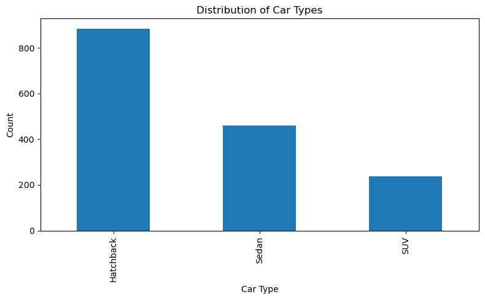

```
Make
Hatchback   55.90
Sedan       29.10
SUV         15.00
Name: proportion, dtype: float64
```

```python
# Basic frequency chart for car types
df["Make"].value_counts().plot(kind="bar")
plt.title("Distribution of Car Types")
plt.xlabel("Car Type"); plt.ylabel("Count")
plt.tight_layout(); plt.show()

# Show the same distribution in percentages (easier to quote in slides)
df["Make"].value_counts(normalize=True).mul(100).round(1)
```

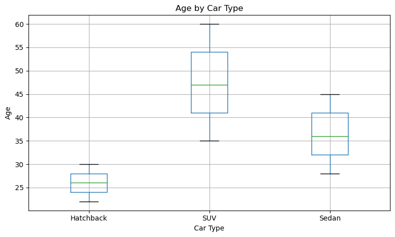

| Make | count | mean | median | min | max |
| --- | --- | --- | --- | --- | --- |
| Hatchback | 884 | 25.90 | 26.00 | 22 | 30 |
| SUV | 237 | 47.60 | 47.00 | 35 | 60 |
| Sedan | 460 | 36.50 | 36.00 | 28 | 45 |

```python
# Boxplot shows median (line), IQR (box), and outliers.
# Use it to describe which segments skew younger/older.
df.boxplot(column="Age", by="Make")
plt.title("Age by Car Type"); plt.suptitle("")  # remove auto subtitle
plt.xlabel("Car Type"); plt.ylabel("Age")
plt.tight_layout(); plt.show()

# Table for precise numbers to cite (mean/median/min/max)
df.groupby("Make")["Age"].agg(["count","mean","median","min","max"]).round(1)
```

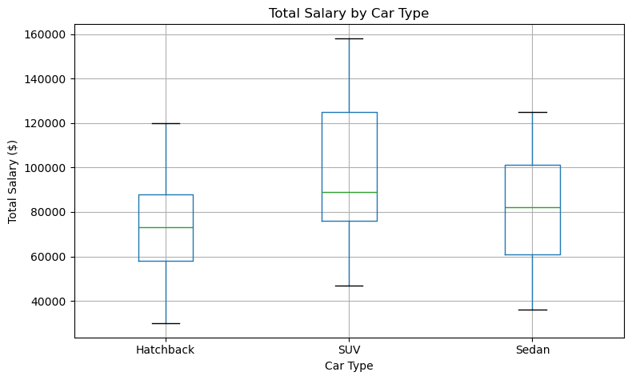

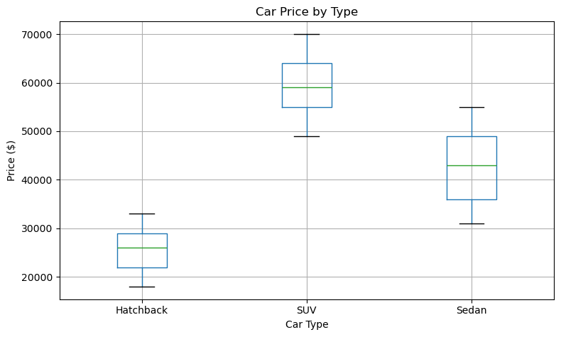

| Make | Total_salary mean | Total_salary median | Price mean | Price median |
| --- | --- | --- | --- | --- |
| Hatchback | 72,676.00 | 73,000.00 | 25,561.00 | 26,000.00 |
| SUV | 99,316.00 | 89,000.00 | 59,304.00 | 59,000.00 |
| Sedan | 82,241.00 | 82,000.00 | 42,672.00 | 43,000.00 |

```python
# Total salary distribution by Make
df.boxplot(column="Total_salary", by="Make")
plt.title("Total Salary by Car Type"); plt.suptitle("")
plt.xlabel("Car Type"); plt.ylabel("Total Salary ($)")
plt.tight_layout(); plt.show()

# Price distribution by Make
df.boxplot(column="Price", by="Make")
plt.title("Car Price by Type"); plt.suptitle("")
plt.xlabel("Car Type"); plt.ylabel("Price ($)")
plt.tight_layout(); plt.show()

# Summary table to quote exact values in findings
df.groupby("Make")[["Total_salary","Price"]].agg(["mean","median"]).round(0)
```

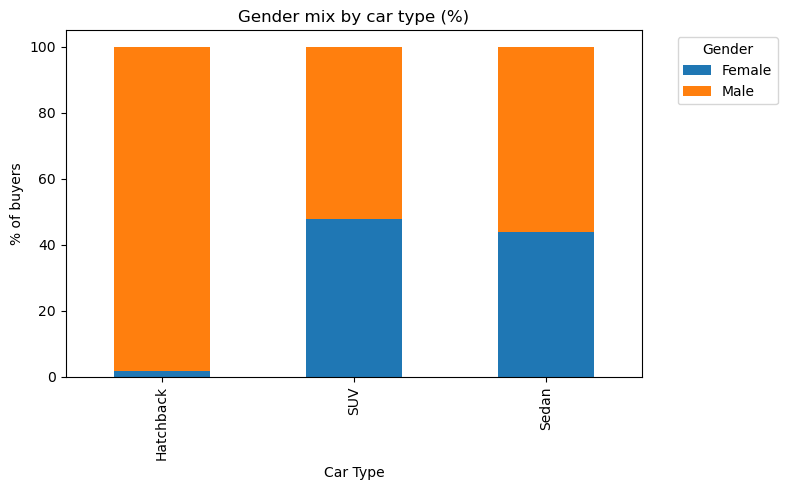

| Gender Make | Female | Male |
| --- | --- | --- |
| Hatchback | 1.70 | 98.30 |
| SUV | 47.70 | 52.30 |
| Sedan | 43.70 | 56.30 |

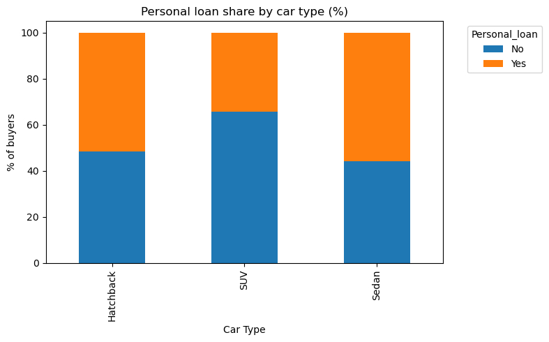

| Personal_loan Make | No | Yes |
| --- | --- | --- |
| Hatchback | 48.50 | 51.50 |
| SUV | 65.80 | 34.20 |
| Sedan | 44.30 | 55.70 |

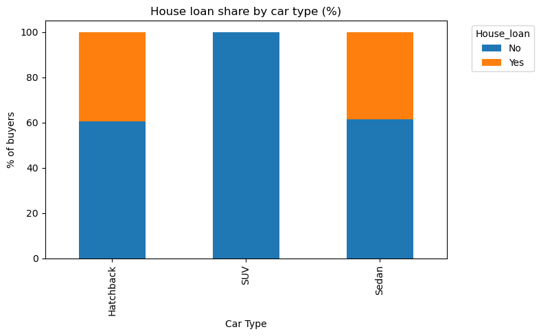

| House_loan Make | No | Yes |
| --- | --- | --- |
| Hatchback | 60.50 | 39.50 |
| SUV | 100.00 | 0.00 |
| Sedan | 61.30 | 38.70 |

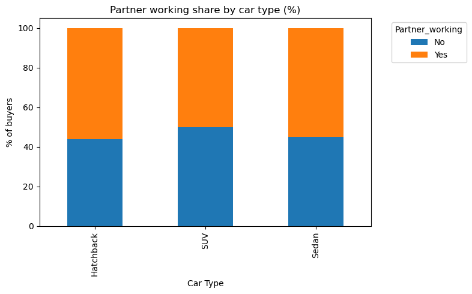

| Partner_working Make | No | Yes |
| --- | --- | --- |
| Hatchback | 43.80 | 56.20 |
| SUV | 49.80 | 50.20 |
| Sedan | 45.20 | 54.80 |

```python
# Loop through key categorical features to see composition inside each Make.
for col, title in [
    ("Gender", "Gender mix by car type (%)"),
    ("Personal_loan", "Personal loan share by car type (%)"),
    ("House_loan", "House loan share by car type (%)"),
    ("Partner_working", "Partner working share by car type (%)"),
]:
    pct = pct_crosstab("Make", col)
    stacked_bar_from_pct(pct, title, "Car Type")
    display(pct)  # show the underlying % table for precise quoting
```